# Iowa 2016 Presidential Primary Contributions Analysis, by Moiz Kapadia

# Univariate Plots Section

```
##  [1] "cmte_id"           "cand_id"           "cand_nm"
##  [4] "contbr_nm"         "contbr_city"       "contbr_st"
##  [7] "contbr_zip"        "contbr_employer"   "contbr_occupation"
## [10] "contb_receipt_amt" "contb_receipt_dt"  "receipt_desc"
## [13] "memo_cd"           "memo_text"         "form_tp"
## [16] "file_num"          "tran_id"           "election_tp"
```

```
## 'data.frame':    10098 obs. of  18 variables:
##  $ cmte_id          : Factor w/ 21 levels "C00458844","C00500587",..: 1 1 1 1 7 7 7 1 7 7 ...
##  $ cand_id          : Factor w/ 21 levels "P00003392","P20002721",..: 9 9 9 9 10 10 10 9 10 10 ...
##  $ cand_nm          : Factor w/ 21 levels "Bush, Jeb","Carson, Benjamin S.",..: 16 16 16 16 17 17 17 16 17 17 ...
##  $ contbr_nm        : Factor w/ 2920 levels "ABBOTT, STEVEN",..: 1198 1198 1198 1198 2624 99 1298 349 1774 1971 ...
##  $ contbr_city      : Factor w/ 458 levels "ACKLEY","ADAIR",..: 317 317 317 317 104 112 438 72 305 423 ...
##  $ contbr_st        : Factor w/ 1 level "IA": 1 1 1 1 1 1 1 1 1 1 ...
##  $ contbr_zip       : int  513552595 513552595 513552595 513552595 528011742 503122338 523589658 50050 502082253 514667536 ...
##  $ contbr_employer  : Factor w/ 1105 levels "","21ST CENTURY REHAB P.C.",..: 449 449 449 449 692 692 1032 425 692 140 ...
##  $ contbr_occupation: Factor w/ 855 levels "","'MAINTENANCE'",..: 362 362 362 362 496 342 728 342 496 440 ...
##  $ contb_receipt_amt: num  200 100 200 100 156 ...
##  $ contb_receipt_dt : Factor w/ 318 levels "1-Apr-15","1-Aug-15",..: 197 100 184 246 242 126 242 53 242 10 ...
##  $ receipt_desc     : Factor w/ 11 levels "","REATTRIBUTION / REDESIGNATION REQUESTED",..: 1 1 1 1 1 1 1 1 1 1 ...
##  $ memo_cd          : Factor w/ 2 levels "","X": 1 1 1 1 1 1 1 1 1 1 ...
##  $ memo_text        : Factor w/ 34 levels "","* EARMARKED CONTRIBUTION: SEE BELOW",..: 1 1 1 1 1 2 2 1 2 2 ...
##  $ form_tp          : Factor w/ 3 levels "SA17A","SA18",..: 1 1 1 1 1 1 1 1 1 1 ...
##  $ file_num         : int  1029436 1029436 1029436 1029436 1029414 1029414 1029414 1029436 1029414 1029414 ...
##  $ tran_id          : Factor w/ 10078 levels "A009A28F250C54B6F819",..: 5411 5479 5579 5590 7716 7630 7650 5395 7654 7663 ...
##  $ election_tp      : Factor w/ 3 levels "","G2016","P2016": 3 3 3 3 3 3 3 3 3 3 ...
```

```
##                 Bush, Jeb       Carson, Benjamin S.
##                       156                      2264
##  Christie, Christopher J.   Clinton, Hillary Rodham
##                        40                      1463
## Cruz, Rafael Edward 'Ted'            Fiorina, Carly
##                      2211                       288
##        Graham, Lindsey O.            Huckabee, Mike
##                        18                        98
##             Jindal, Bobby           Kasich, John R.
##                        14                        49
##          Lessig, Lawrence   O'Malley, Martin Joseph
##                         4                       117
##         Pataki, George E.                Paul, Rand
##                         1                       298
##    Perry, James R. (Rick)              Rubio, Marco
##                         3                       402
##          Sanders, Bernard      Santorum, Richard J.
##                      2506                        61
##          Trump, Donald J.             Walker, Scott
##                        46                        56
##     Webb, James Henry Jr.
##                         3
```

##### I added the political party of each candidate as a variable so that I can make an analysis based on Republicans and Democrats. These tables show me how many people contributed to the campaigns of each candidate. In addition to how many people contributed, how much did each candidate raise? I’ll explore this later on.

```
##
##                 Bush, Jeb       Carson, Benjamin S.
##                         0                         0
##  Christie, Christopher J.   Clinton, Hillary Rodham
##                         0                      1463
## Cruz, Rafael Edward 'Ted'            Fiorina, Carly
##                         0                         0
##        Graham, Lindsey O.            Huckabee, Mike
##                         0                         0
##             Jindal, Bobby           Kasich, John R.
##                         0                         0
##          Lessig, Lawrence   O'Malley, Martin Joseph
##                         4                       117
##         Pataki, George E.                Paul, Rand
##                         0                         0
##    Perry, James R. (Rick)              Rubio, Marco
##                         0                         0
##          Sanders, Bernard      Santorum, Richard J.
##                      2506                         0
##          Trump, Donald J.             Walker, Scott
##                         0                         0
##     Webb, James Henry Jr.
##                         3
```

```
##
##                 Bush, Jeb       Carson, Benjamin S.
##                       156                      2264
##  Christie, Christopher J.   Clinton, Hillary Rodham
##                        40                         0
## Cruz, Rafael Edward 'Ted'            Fiorina, Carly
##                      2211                       288
##        Graham, Lindsey O.            Huckabee, Mike
##                        18                        98
##             Jindal, Bobby           Kasich, John R.
##                        14                        49
##          Lessig, Lawrence   O'Malley, Martin Joseph
##                         0                         0
##         Pataki, George E.                Paul, Rand
##                         1                       298
##    Perry, James R. (Rick)              Rubio, Marco
##                         3                       402
##          Sanders, Bernard      Santorum, Richard J.
##                         0                        61
##          Trump, Donald J.             Walker, Scott
##                        46                        56
##     Webb, James Henry Jr.
##                         0
```

##### I added the gender of each candidate as a variable. These tables show me how many people contributed to each candidate based on their gender. Again, I’m wondering how much did each candidate raise? Also, how do Hillary Clinton and Carly Fiorina compare as the the only women in the race?

```
##
##                 Bush, Jeb       Carson, Benjamin S.
##                       156                      2264
##  Christie, Christopher J.   Clinton, Hillary Rodham
##                        40                         0
## Cruz, Rafael Edward 'Ted'            Fiorina, Carly
##                      2211                         0
##        Graham, Lindsey O.            Huckabee, Mike
##                        18                        98
##             Jindal, Bobby           Kasich, John R.
##                        14                        49
##          Lessig, Lawrence   O'Malley, Martin Joseph
##                         4                       117
##         Pataki, George E.                Paul, Rand
##                         1                       298
##    Perry, James R. (Rick)              Rubio, Marco
##                         3                       402
##          Sanders, Bernard      Santorum, Richard J.
##                      2506                        61
##          Trump, Donald J.             Walker, Scott
##                        46                        56
##     Webb, James Henry Jr.
##                         3
```

```
##
##                 Bush, Jeb       Carson, Benjamin S.
##                         0                         0
##  Christie, Christopher J.   Clinton, Hillary Rodham
##                         0                      1463
## Cruz, Rafael Edward 'Ted'            Fiorina, Carly
##                         0                       288
##        Graham, Lindsey O.            Huckabee, Mike
##                         0                         0
##             Jindal, Bobby           Kasich, John R.
##                         0                         0
##          Lessig, Lawrence   O'Malley, Martin Joseph
##                         0                         0
##         Pataki, George E.                Paul, Rand
##                         0                         0
##    Perry, James R. (Rick)              Rubio, Marco
##                         0                         0
##          Sanders, Bernard      Santorum, Richard J.
##                         0                         0
##          Trump, Donald J.             Walker, Scott
##                         0                         0
##     Webb, James Henry Jr.
##                         0
```

```
##    Min. 1st Qu.  Median    Mean 3rd Qu.    Max.
## -7300.0    25.0    50.0   155.9   100.0 10000.0
```

##### These are summary statistics on contribution amounts. Interesting that someone requested a refund of $7,300. The median is a good statistic to look at here, because the mean is thrown off by the width of range.

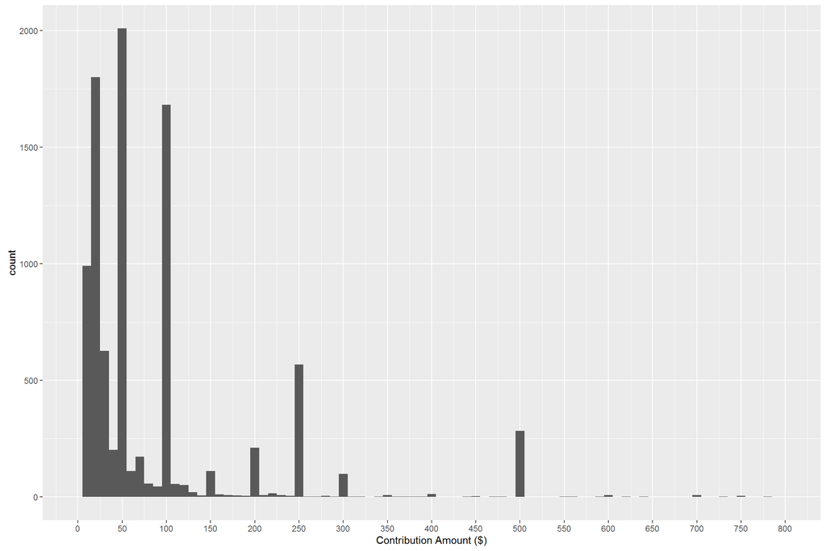

##### The graph above shows the contributions across both parties. Looks like the majority of the contributions were below $100, and $50 is the most frequent contribution. I wonder what this looks like between parties?

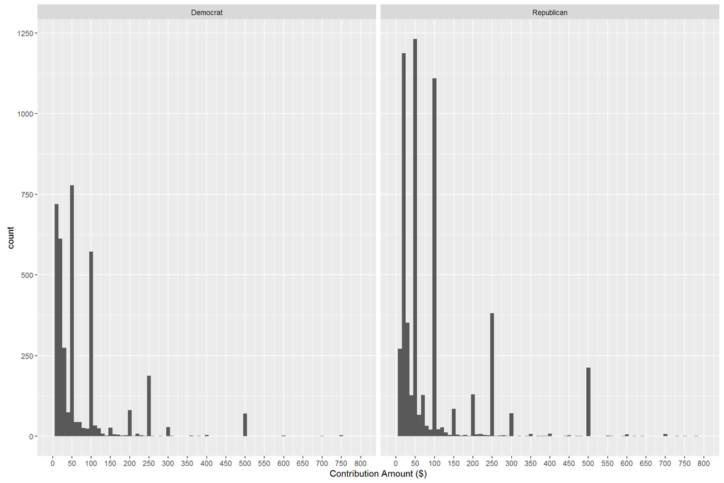

##### Frequency poly graph to view the data in a different way.

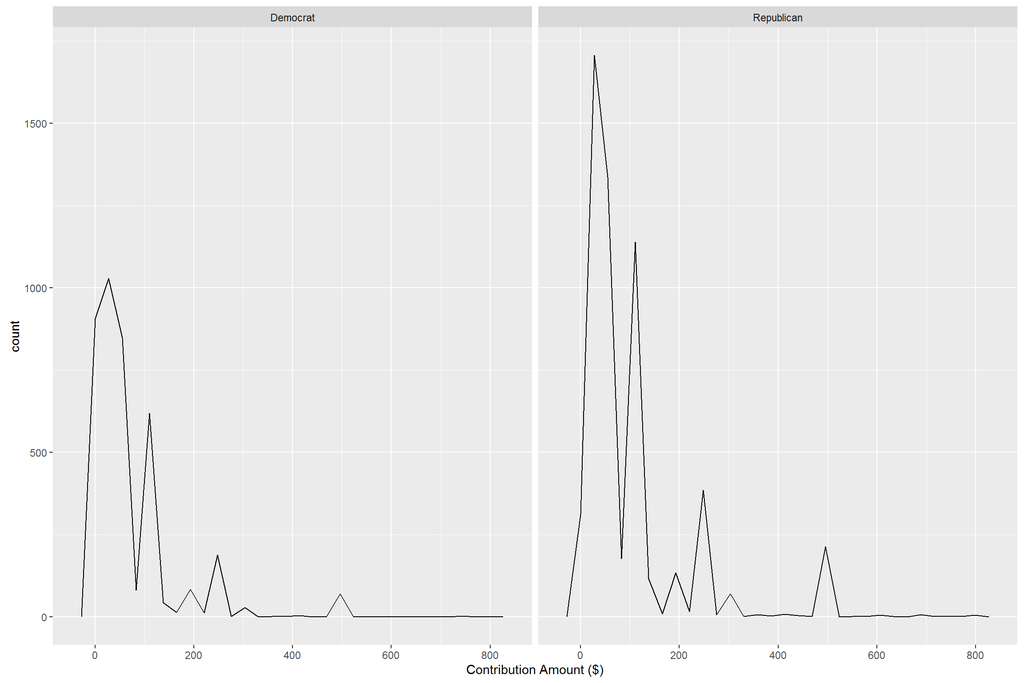

##### The histogram hints that Republicans had more people contributing to them than the Democrats. Let me confirm this by finding the total sum donated to each party.

```
## [1] "Total Republican Contributions:"
```

```
## [1] 1024318
```

```
## [1] "Total Democratic Contributions:"
```

```
## [1] 550276.1
```

##### It’s true. Republican Iowans donated almost twice as much money than Democrat Iowans. However the contributions are most likely higher because there are more Republican candidates in the race.

##### I can see that both data sets have a long tails, so I’d like to transform them to see how the data looks.

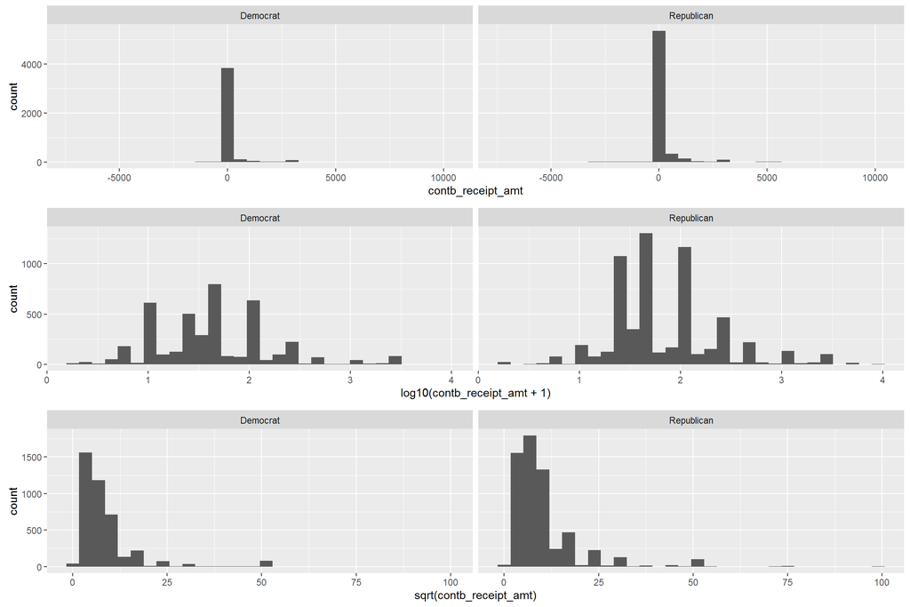

##### It looks like the log based plot shows a normal distribution of contributions. I’ll finish exploring by seeing what a log based frequency plot looks like.

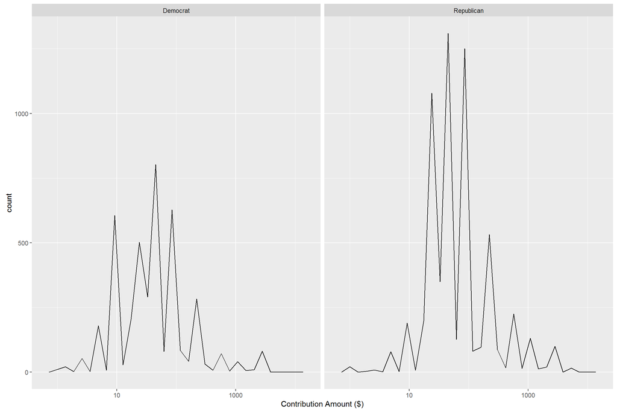

##### Next, I wanted to see how contributions varied across the cities.

```
##      DES MOINES       IOWA CITY    CEDAR RAPIDS       URBANDALE
##             767             663             504             409
## WEST DES MOINES       DAVENPORT          ANKENY      BETTENDORF
##             386             383             300             266
##            AMES         DUBUQUE        WATERLOO      SIOUX CITY
##             252             230             191             165
##          MARION  COUNCIL BLUFFS           CLIVE     CEDAR FALLS
##             129             128             126             124
##      BURLINGTON         CLINTON          WAUKEE       FAIRFIELD
##             119             106             104             102
##         DECORAH          KALONA      CORALVILLE        JOHNSTON
##              84              83              78              68
##    MARSHALLTOWN         SPENCER         OTTUMWA          NEWTON
##              68              67              63              59
##           PELLA      WASHINGTON           BOONE            ADEL
##              56              53              52              51
##       MUSCATINE      FORT DODGE        GLENWOOD         DE WITT
##              51              49              47              46
##      MASON CITY     SPIRIT LAKE            COLO         WAVERLY
##              45              43              42              42
##     WEST BRANCH        ATLANTIC    SIOUX CENTER      STORM LAKE
##              42              41              41              39
##         ALTOONA         MILFORD     ORANGE CITY          HARLAN
##              37              35              33              31
##         SHELDON           ALBIA    CHARLES CITY WINDSOR HEIGHTS
##              31              30              30              30
##          ACKLEY            ALTA       INDIANOLA         NORWALK
##              29              29              29              29
##         CORYDON         LE MARS        GRINNELL      IOWA FALLS
##              28              28              27              27
##        CHARITON         SWISHER    WEBSTER CITY     CENTERVILLE
##              26              26              26              25
##           CLARE         ZWINGLE        CLARINDA          GARNER
##              25              25              24              24
##          HUXLEY          TIPTON      CLEAR LAKE          GRIMES
##              24              24              23              23
##         CARROLL         WELLMAN        CAMANCHE         CRESTON
##              22              22              21              21
##         DENISON       OSKALOOSA           SOLON         ANAMOSA
##              21              21              21              20
##      MANCHESTER  SERGEANT BLUFF        WOODBINE        ELDRIDGE
##              20              20              20              19
##      JANESVILLE          KELLEY         KELLOGG          KEOKUK
##              19              19              19              19
##         LATIMER       LE CLAIRE          NEVADA   PLEASANT HILL
##              19              19              19              19
##      STORY CITY      WEST UNION           DOUDS    MOUNT VERNON
##              19              19              18              18
##   NORTH LIBERTY     FOREST CITY        HIAWATHA         (Other)
##              18              17              17            2030
```

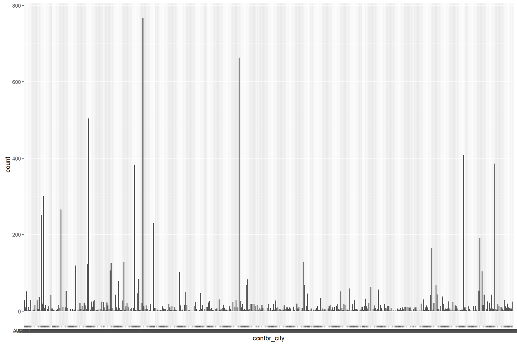

##### I see there are ~15 that cities that had the highest number of contributions. Which cities made those contributions, how much, and who did they donate to? These are questions I’ll save for bivariate or multivariate analysis. I created a dataset which counts the frequency of each city’s contribution, to view the data in a different way.

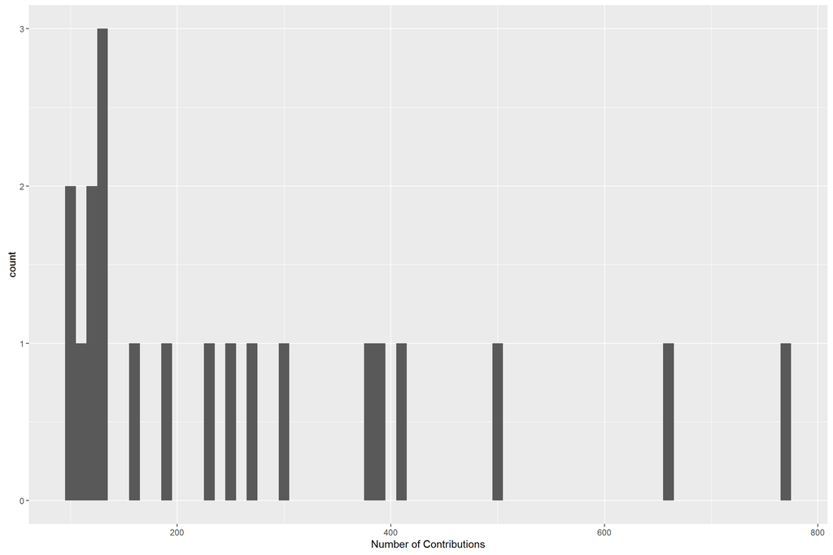

##### Next, I looked at how contributions varied across occupations.

```
##                                RETIRED
##                                   2788
##                           NOT EMPLOYED
##                                    720
## INFORMATION REQUESTED PER BEST EFFORTS
##                                    368
##                                 FARMER
##                                    306
##                              HOMEMAKER
##                                    270
##                              PROFESSOR
##                                    174
##                              PHYSICIAN
##                                    157
##                  INFORMATION REQUESTED
##                                    137
##                               ENGINEER
##                                    108
##                               ATTORNEY
##                                    107
##                                   NONE
##                                     85
##                       REGISTERED NURSE
##                                     80
##                                TEACHER
##                                     77
##                              PRESIDENT
##                                     71
##                             CONSULTANT
##                                     70
##                                  OWNER
##                                     70
##                          SELF EMPLOYED
##                                     64
##                                 PASTOR
##                                     60
##                                MANAGER
##                                     54
##                                     RN
##                                     53
```

[output cut: 145 more lines]

```
##                                     13
##                                 WRITER
##                                     13
##                  100% DISABLED VETERAN
##                                     12
##                             BOOKKEEPER
##                                     12
##                       DISABLED VETERAN
##                                     12
##              PROFESSIONAL TRUCK DRIVER
##                                     12
##                                (Other)
##                                   2564
##                                   NA's
##                                      6
```

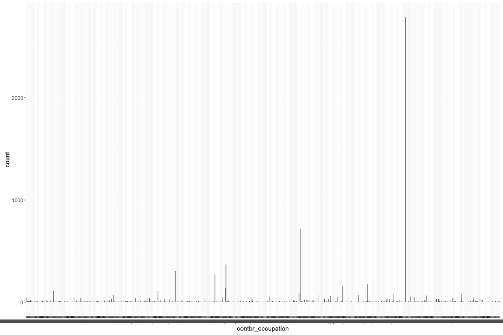

```
## Source: local data frame [856 x 2]
##
##                         contbr_occupation     n
##                                    (fctr) (int)
## 1                                 RETIRED  2788
## 2                            NOT EMPLOYED   720
## 3  INFORMATION REQUESTED PER BEST EFFORTS   368
## 4                                  FARMER   306
## 5                               HOMEMAKER   270
## 6                               PROFESSOR   174
## 7                               PHYSICIAN   157
## 8                   INFORMATION REQUESTED   137
## 9                                ENGINEER   108
## 10                               ATTORNEY   107
## ..                                    ...   ...
```

##### Similar to cities, I see there are ~5 occupations that make the most contributions. Which occupations made these contributions, how much, and who did they donate to? These are questions I’ll answer in bivariate analysis.

# Univariate Analysis

### What is the structure of your dataset?

##### This dataset contains 10,098 observations of 18 variables, which includes information about the candidate information about the contributor, and seemingly administrative information related to processing the contribution. The contributor information includes name, city, contribution amount, etc. This dataset has 15 Factor variables and 3 numeric variables.

##### The contributions ranged from $10,0000 to a refund of $7300, with a mean of $155.9 and median of $50. Most of the contributions were made by Retirees and most of the contributions came from Des Moines.

### What are the main features of your dataset?

##### The main features are the candidate, contribution amount, the occupation of the contributor, and the city that the contributor resides in.

### What other features in the dataset do you think will help support your investigation into your feature(s) of interest?

### Did you create any new variables from existing variables in the dataset?

##### I added political party and gender of each candidate. I searched for the 2016 Iowa Caucus results to make sure that I assigned each candidate to the correct party.

### Of the features you investigated, were there any unusual distributions? Did you perform any operations on the data to tidy, adjust, or change the form of the data? If so, why did you do this?

# Bivariate Plots

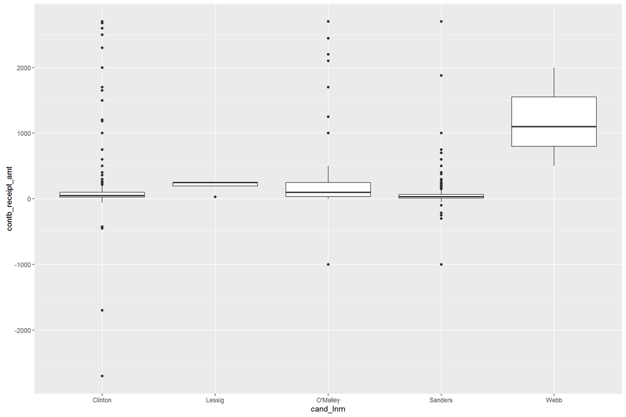

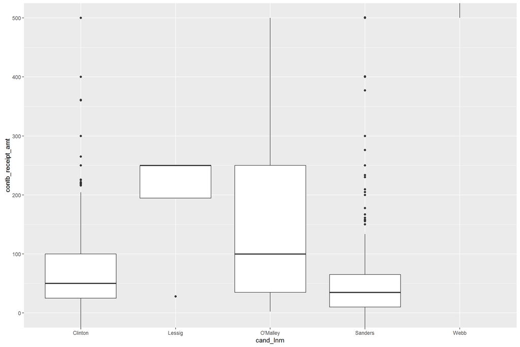

##### The two plots above are boxplots of contributions made to Democrats. It’s clear that Jim Webb’s contributions were well outside the range of the other candidiates. I zoomed in on the other 4 candidates to find that the median for Clinton and Sanders was around $50. O’Malley came in at $100, and Lessig at $250.

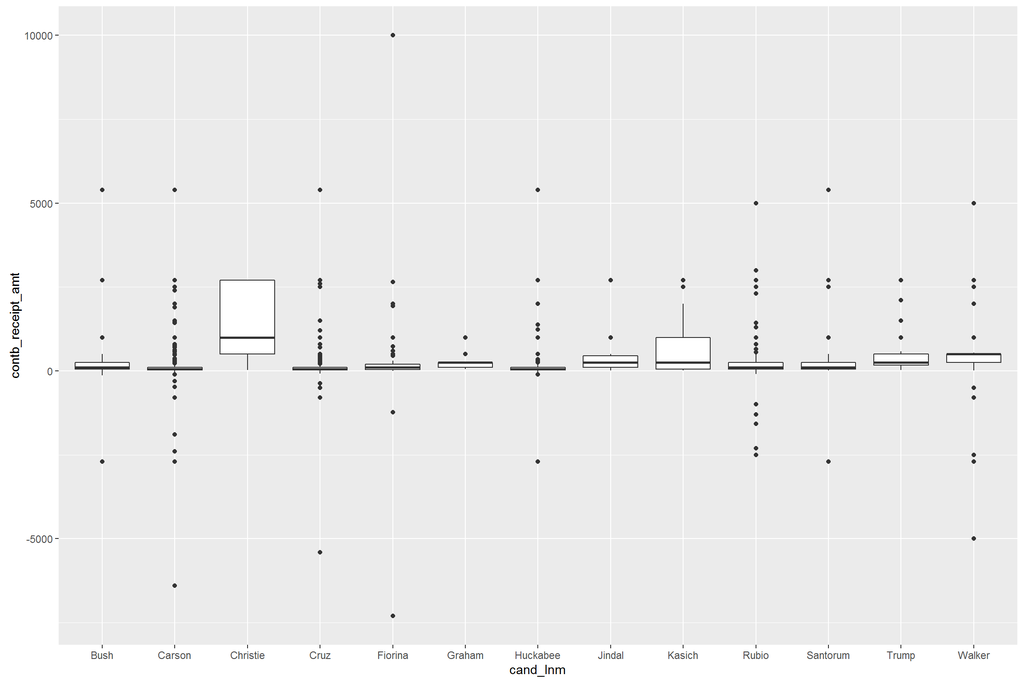

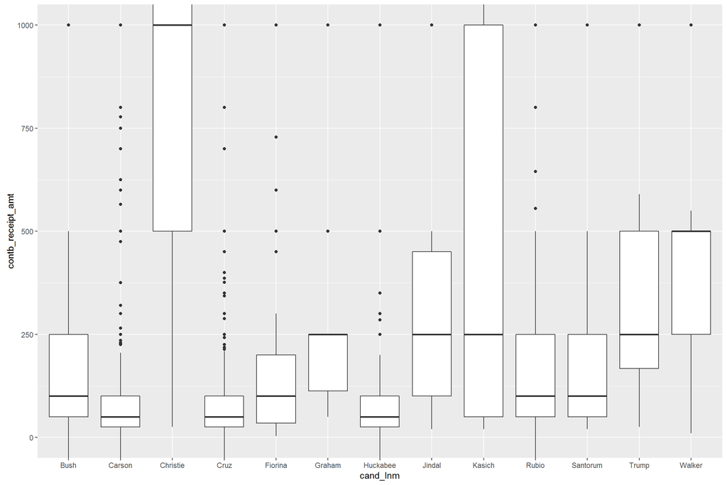

##### The two plots above are boxplots of contributions made to Republicans. I zoomed into the data to get a clearer picture. The chart shows that median is around ~$100 for 7 of the candidates, with 4 candidates having a median at ~$250.

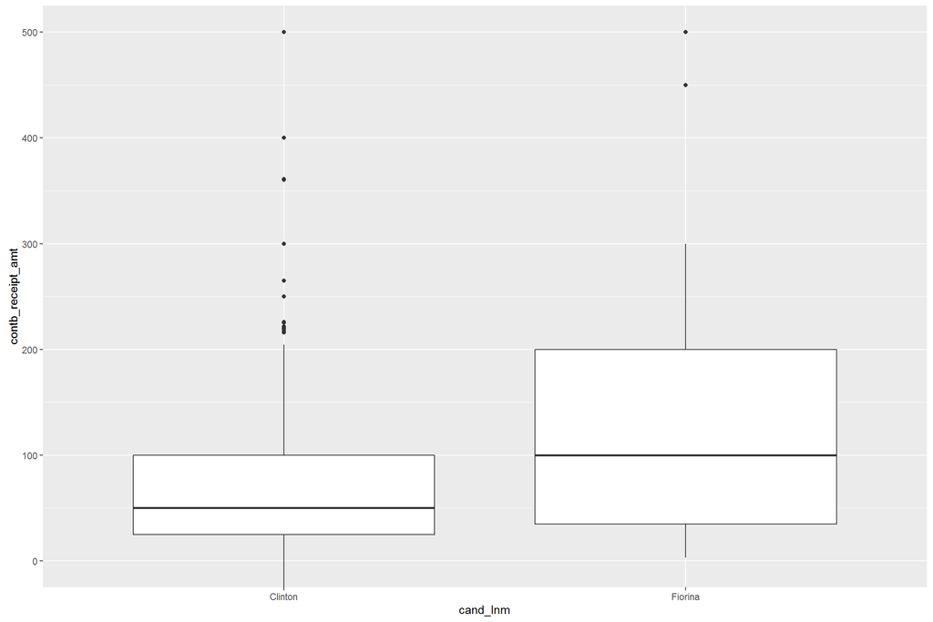

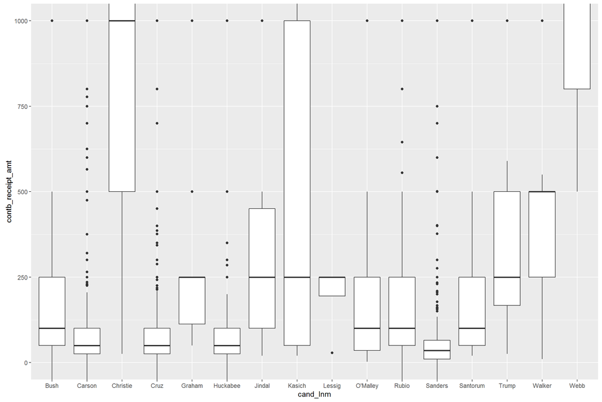

##### The two boxplots show the comparisos by male and female candidates.

##### While these charts give a quick visual of how the candidates performed, its best to create a table that summarizes the statistics for each candidate.

```
##   (cand_lnm)         total_contb         mean_contb       median_contb
##  Length:19          Min.   :   777.9   Min.   :  67.92   Min.   :  35.00
##  Class :character   1st Qu.: 21209.8   1st Qu.: 220.94   1st Qu.:  73.19
##  Mode  :character   Median : 32757.7   Median : 280.56   Median : 100.00
##                     Mean   : 82873.4   Mean   : 409.97   Mean   : 246.39
##                     3rd Qu.: 97508.5   3rd Qu.: 485.27   3rd Qu.: 250.00
##                     Max.   :342931.4   Max.   :1324.38   Max.   :1100.00
##        n
##  Min.   :   3.0
##  1st Qu.:  43.0
##  Median :  98.0
##  Mean   : 531.5
##  3rd Qu.: 352.0
##  Max.   :2506.0
```

```
## Source: local data frame [19 x 5]
##
##    (cand_lnm) total_contb mean_contb median_contb     n
##         (chr)       (dbl)      (dbl)        (dbl) (int)
## 1     Clinton   342931.39  234.40286       50.000  1463
## 2      Carson   274712.90  121.33962       50.000  2264
## 3        Cruz   228626.05  103.40391       50.000  2211
## 4     Sanders   170209.09   67.92063       35.000  2506
## 5       Rubio   121476.05  302.17923      100.000   402
## 6          NA    73540.87  243.51281       96.375   302
## 7        Bush    71108.00  455.82051      100.000   156
## 8     Fiorina    59751.40  207.47014      100.000   288
## 9    Christie    52975.00 1324.37500     1000.000    40
## 10   O'Malley    32757.70  279.98034      100.000   117
## 11     Kasich    31686.00  646.65306      250.000    49
## 12     Walker    28670.00  511.96429      500.000    56
## 13      Trump    27882.39  606.13891      250.000    46
## 14   Huckabee    23380.22  238.57367       50.000    98
## 15   Santorum    19039.41  312.12148      100.000    61
## 16     Jindal     6420.16  458.58286      250.000    14
## 17     Graham     5050.00  280.55556      250.000    18
## 18       Webb     3600.00 1200.00000     1100.000     3
## 19     Lessig      777.94  194.48500      250.000     4
```

##### Hillary Clinton had the most contributions with Ben Carson following in second place. Another interesting feature is the number of contributions each candidate received. Bernie Sanders had the most number of contributors with 2506, Cruz and Carson had similar numbers around 2200, and Clinton had 1463 contributors. The rest of the candidates didn’t get more than 400 contributors. Finally, the mean of the means is $400, and the median of the medians is a $100. Since there is such a large range in the values, the median is a representative number.

##### Now I’d like to visualze the total contributions for each person in bar charts separated by party.

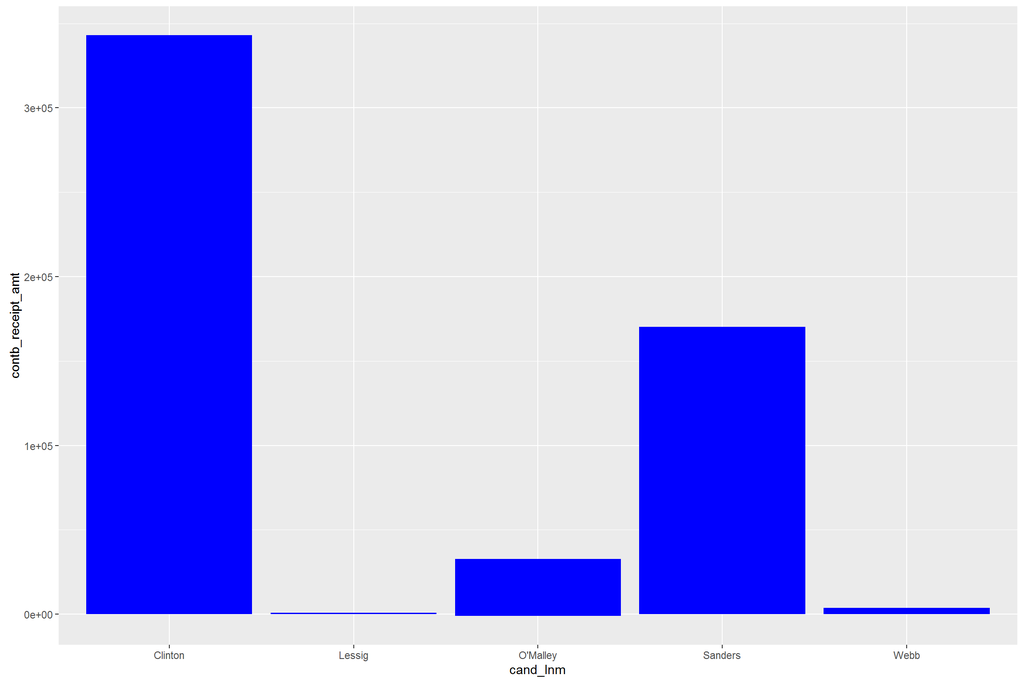

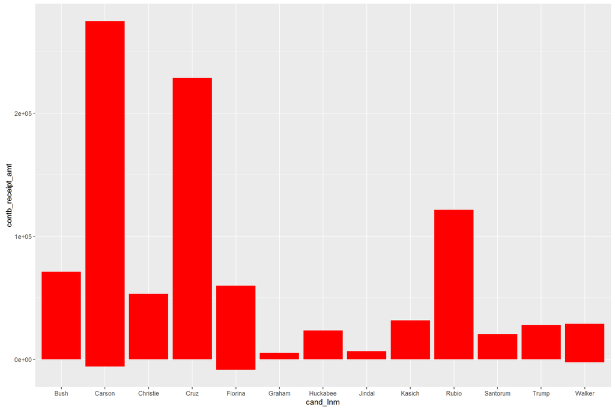

##### These bar plots show which candidate received the most contributions. For the Democrats it was Clinton and Sanders. Clinton raised over $300k while Sanders raised just under $200k. For the Repbulicans it Carson and Cruz raised over $200k and Rubio raised over 100k. The rest of the Republicans raised less than $100k from individual contributors.

```
##    (party)           total_contb        mean_contb     median_contb
##  Length:2           Min.   : 550276   Min.   :134.4   Min.   :50
##  Class :character   1st Qu.: 668787   1st Qu.:143.5   1st Qu.:50
##  Mode  :character   Median : 787297   Median :152.5   Median :50
##                     Mean   : 787297   Mean   :152.5   Mean   :50
##                     3rd Qu.: 905808   3rd Qu.:161.5   3rd Qu.:50
##                     Max.   :1024318   Max.   :170.6   Max.   :50
##        n
##  Min.   :4093
##  1st Qu.:4571
##  Median :5049
##  Mean   :5049
##  3rd Qu.:5527
##  Max.   :6005
```

```
## Source: local data frame [2 x 5]
##
##      (party) total_contb mean_contb median_contb     n
##        (chr)       (dbl)      (dbl)        (dbl) (int)
## 1 Republican   1024318.4   170.5776           50  6005
## 2   Democrat    550276.1   134.4432           50  4093
```

##### This table makes it easy to see that the Republicans raised more money and had more contributors than the Democrats.

##### I’d like to find out how much the Top 10 Cities of Iowa contributers gave.

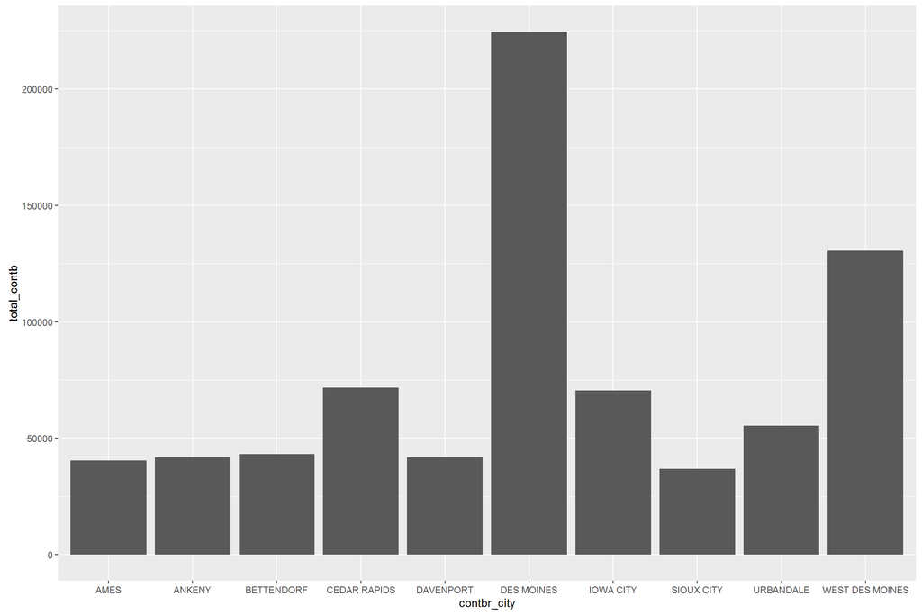

##### Clearly Des Moines, the capital of Iowa, contributed the most dollars to the campaign with over $200k. West Des Moines was a far second place with around $125k. The rest of the cities all contributed less than $75k. This graph leads me to ask to which party do these downs typically give? In the multi-variate plots section, I’ll add differentiate between Republican and Democrat.

##### I’d like to find out how much the Top 10 Occupations of Iowa contributers gave.

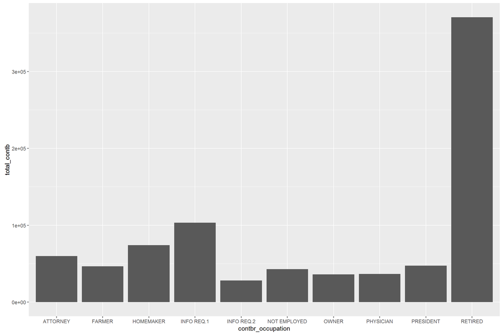

##### The chart clearly shows that Retirees contributed by far the most amounts. It would be great to have more information about the “INFORMATION REQUESTED” groups. This graph leads me to ask to which party do these occupations typically give? In the multi-variate plots section, I’ll add differentiate between Republican and Democrat.

### Talk about some of the relationships you observed in this part of the investigation. How did the feature(s) of interest vary with other features in the dataset?

##### I found that the Republicans raised ~$1M compared to ~$550k raised by Democrats. Hillary Clinton raised the most amount of money as a female Democrat with ~$342k, with Bernie Sanders behind her as a male Democrat with ~$170k. Ben Carson raised the most amount of money as a Republican with ~$275k.

##### I found that the capital city of Des Moines raised over $200k for all the candidates, which is the highest amount of money raised by any city. West Des Moines came in at a far second place by raising $125k. The rest of the top 10 cities raised around $50k.

##### It was clear that the Retired population of Iowa contributes the most amount of money.

### Did you observe any interesting relationships between the other features (not the main feature(s) of interest)?

##### No, I explored all the variables that describe this dataset.

### What was the strongest relationship you found?

##### The strongest relationship was between how much the Retired population contributed. Candidates running in Iowa should target the retired population since they are very active in the political process.

# Multi-variate plots

##### To which party do the top 10 Cities of contributers primarily give their money to?

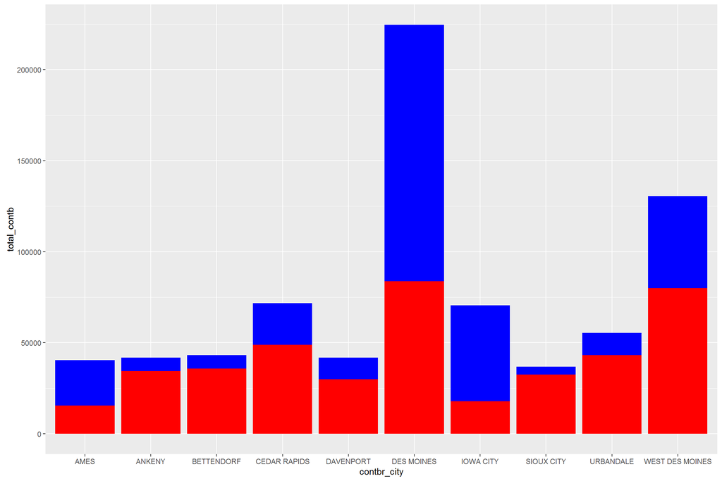

##### The Democrats have the advantage in Des Moines, Iowa City, Ames, while the Republican candidates earned more in the rest of the top contributing cities.

##### To which party do the top 10 Occupations of contributers primarily give their money to?

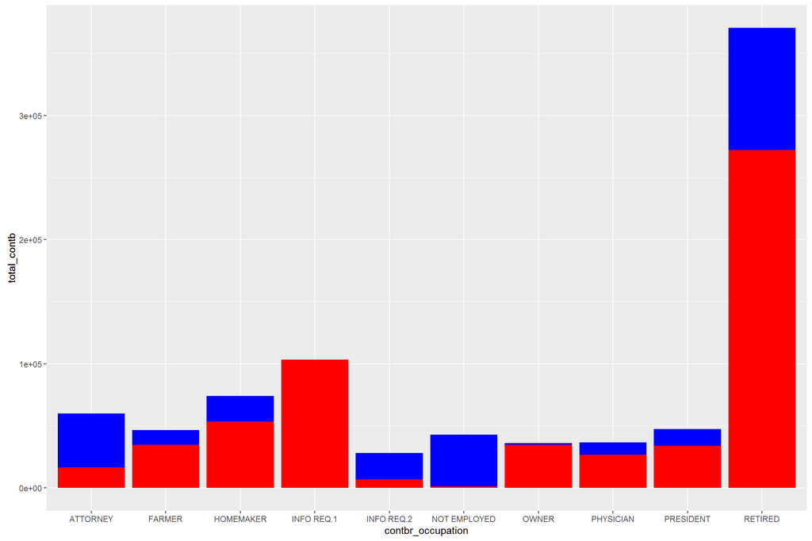

##### Retirees overwhelmingly support Republicans, as do most of the occupations in Iowa. It would be interesting to know who the people in the “INFORMATION REQUESTED” categories are since one favors Republicans and the other favors Democrats. Most interesting in this chart is that the unemployed support Democrats.

##### Since Retirees contribute so much to the candidates, I’m curious to see who they support

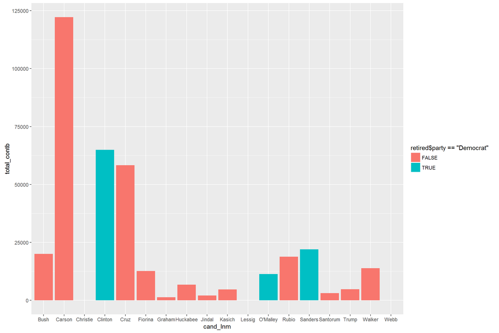

## Talk about some of the relationships you observed in this part of the investigation. Were there features that strengthened each other in terms of looking at your feature(s) of interest?

##### It was very interesting to add the third dimension of the party onto each of the charts. It clearly showed which city and occupation leans Republican or Democrat. These charts then lead to the natural question of which did these occupations or cities support the most?

## Were there any interesting or surprising interactions between features?

##### Since the relationship between Retired Iowans and campaign contributions is so strong, I investigated the Retired population further. I found that Ben Carson had the strongest support from Retirees, with Ted Cruz a distant second. Hillary Clinton had the strongest support for the Democrats.

# Final Plots and Summary

### Plot One

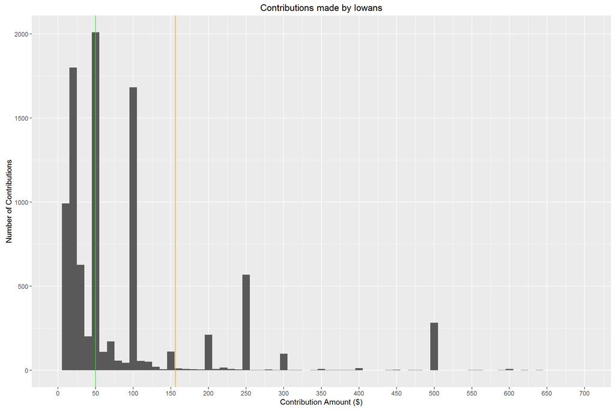

### Plot Two

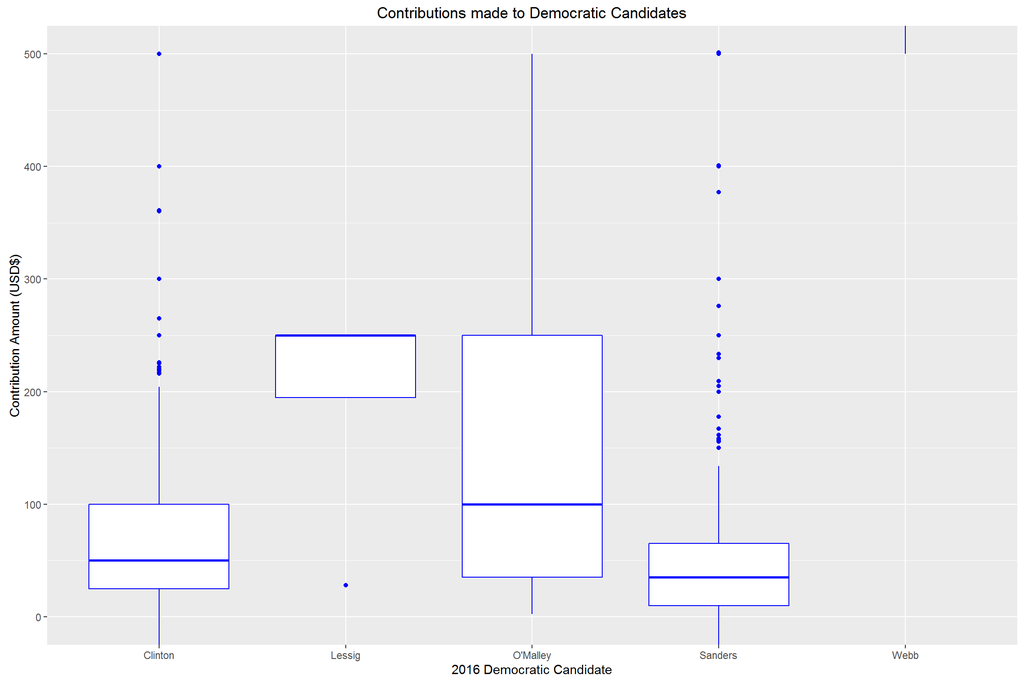

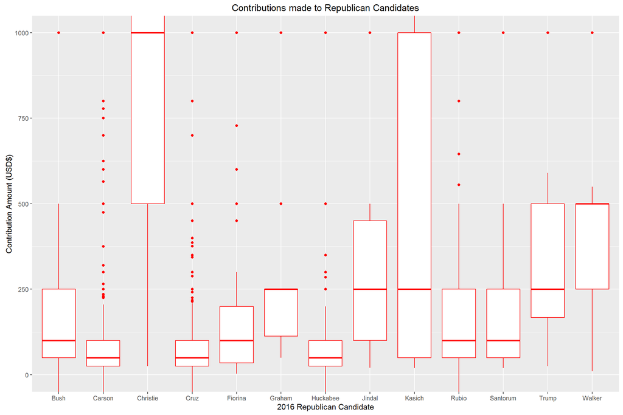

### Plot Three

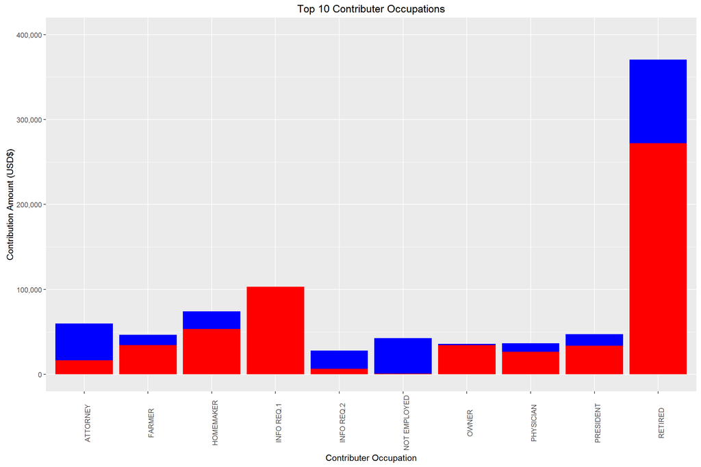

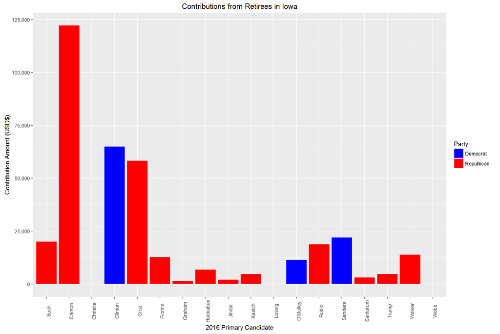

### Description Three

##### The top bar chart shows the Top 10 Contributers by Occupation, split into Republican and Democrat. I chose to make this chart because if I were running a campaign, I’d want to understand which groups are contributing the most money. This would help me target my campaign message, and more importantly figure out who isn’t contributing and why. By understanding who isn’t contributing, I would try to figure out how to bring them into the political process.

##### Clearly the Retirees in Iowa are very politically active, so I wanted to know who Retirees support. The bottom bar chart drills down into which the Retirees in Iowa supported, by color coding the party of each candidate. Ben Carson, Hillary Clinton, and Ted Cruz were the favorites for the Retirees. It makes sense to me why Retirees are most active, because they are more sensitive to policy changes in healthcare or taxes.

# Reflection

##### These bar charts led me to wonder how the cities and occupations broke between Republican and Democrat. This is where adding the party variable really came in handy, because I was easily able to add that layer to the analysis. Since Retirees were such strong contributers I investigated who they supported the most, and found it was Hillary Clinton for the Democrats and Ben Carson for the Republicans.

##### Similarly, one more question I would ask about the data is which candidates did Des Moines support? It would also be interesting to map the data so that its easy to see which cities are contributing the most. This would allow candidates to focus their efforts and investigate whether they should be reaching out to untapped counties.

##### It took me a while to figure out how to add the politcal party and gender of each candidate, but it was well worth it because it added an extra layer of analysis. I really liked learning about chaining functions, I find it very logical and easy to ask questions. Finally, using ggplot2 is great for multi-variate analysis because its easy to layer on addtional forms of data.